# Fundulus similis

Lisa K. Johnson

3/20/2018

# DE by species

The following is a DE analysis with *Fundulus similis* to identify candidate genes for downstream comparative gene expression analysis.

These are the quantification files, and whether they exist:

```
## [1] "../salmon_denovo_by_species/F_similis/F_similis_BW_1.quant/quant.sf"
## [2] "../salmon_denovo_by_species/F_similis/F_similis_BW_2.quant/quant.sf"
## [3] "../salmon_denovo_by_species/F_similis/F_similis_BW_3.quant/quant.sf"
## [4] "../salmon_denovo_by_species/F_similis/F_similis_FW_1.quant/quant.sf"
## [5] "../salmon_denovo_by_species/F_similis/F_similis_FW_2.quant/quant.sf"
## [6] "../salmon_denovo_by_species/F_similis/F_similis_FW_3.quant/quant.sf"
## [7] "../salmon_denovo_by_species/F_similis/F_similis_transfer_1.quant/quant.sf"
## [8] "../salmon_denovo_by_species/F_similis/F_similis_transfer_2.quant/quant.sf"
## [9] "../salmon_denovo_by_species/F_similis/F_similis_transfer_3.quant/quant.sf"
```

```
## [1] TRUE TRUE TRUE TRUE TRUE TRUE TRUE TRUE TRUE
```

# De novo assemblies and annotations

De novo assemblies were run with Trinity (version 2.2.0) and annotated with dammit (version 1.0) with translated amino acid database from the [NCBI version of the Fundulus heteroclitus genome](https://www.ncbi.nlm.nih.gov/genome/743).

(eed to run again with [Don Gilbert’s kfish2rae5g](http://arthropods.eugenes.org/EvidentialGene/killifish/) aa fasta file to get Funhe id)

This resulted in Trinity contigs (transcripts) that were annotated against F. heteroclitus, Pfam, Rfam, and orthodb protein databases. The highest E-value match was selected as an annotated, one per contig. If an annotated contig matched with the F. heteroclitus database, it was kept separately for reference later.

This is the number of contigs:

```
## [1] 520314      1
```

This is the number of annotated contigs:

```
## [1] 161532      8
```

Summarizing by gene:

```
## reading in files with read_tsv
```

```
## 1 2 3 4 5 6 7 8 9
## removing duplicated transcript rows from tx2gene
## transcripts missing from tx2gene: 445760
## summarizing abundance
## summarizing counts
## summarizing length
```

```
## [1] 31247     9
```

# Experimental Design

```
##                            condition
## F_similis_BW_1.quant              BW
## F_similis_BW_2.quant              BW
## F_similis_BW_3.quant              BW
## F_similis_FW_1.quant              FW
## F_similis_FW_2.quant              FW
## F_similis_FW_3.quant              FW
## F_similis_transfer_1.quant        TR
## F_similis_transfer_2.quant        TR
## F_similis_transfer_3.quant        TR
```

# Dispersion

```
## using counts and average transcript lengths from tximport
```

```
## using 'avgTxLength' from assays(dds), correcting for library size
```

```
##      [,1]
## [1,] "Intercept"
## [2,] "condition_FW_vs_BW"
## [3,] "condition_TR_vs_BW"
```

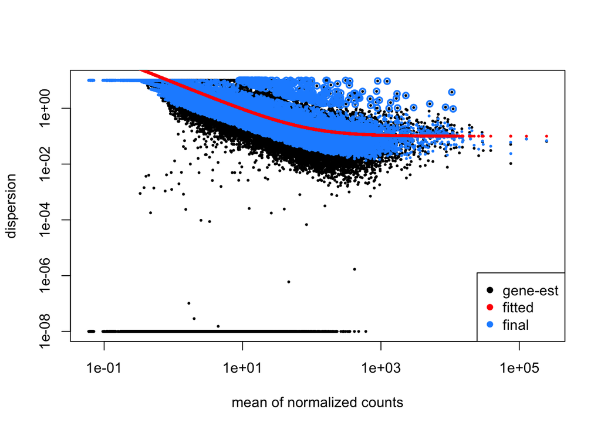

# PCA

```
## Importance of components:
##                            PC1     PC2      PC3     PC4      PC5      PC6
## Standard deviation     41.0350 21.6103 19.50050 19.1862 18.05786 17.76887
## Proportion of Variance  0.4067  0.1128  0.09183  0.0889  0.07875  0.07625
## Cumulative Proportion   0.4067  0.5194  0.61126  0.7002  0.77890  0.85515
##                             PC7      PC8       PC9
## Standard deviation     17.65268 16.97578 1.611e-13
## Proportion of Variance  0.07525  0.06959 0.000e+00
## Cumulative Proportion   0.93041  1.00000 1.000e+00
```

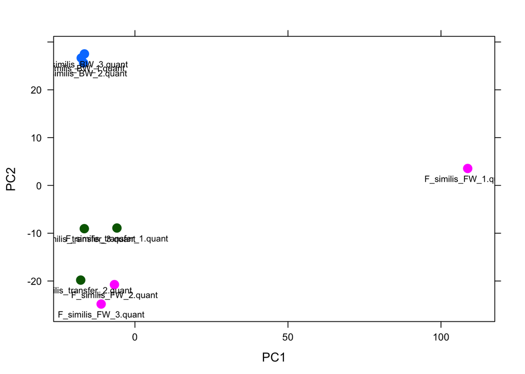

# Get normalized counts and filter out genes with low expression

This is the number of genes in the expression counts table:

```
## [1] 31247     9
```

After filtering for low expression (where th rowSum is greater than or equal to 1):

```
## [1] 18459     9
```

# MA plot, BW vs. FW

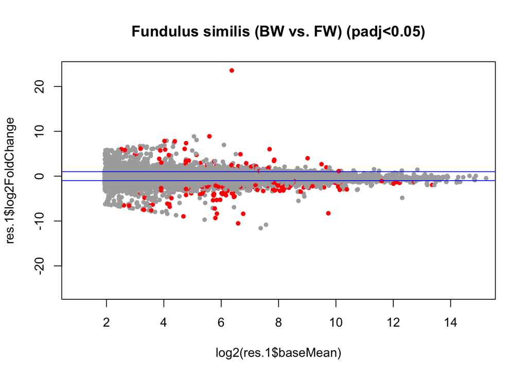

# MA plot, TR vs. FW

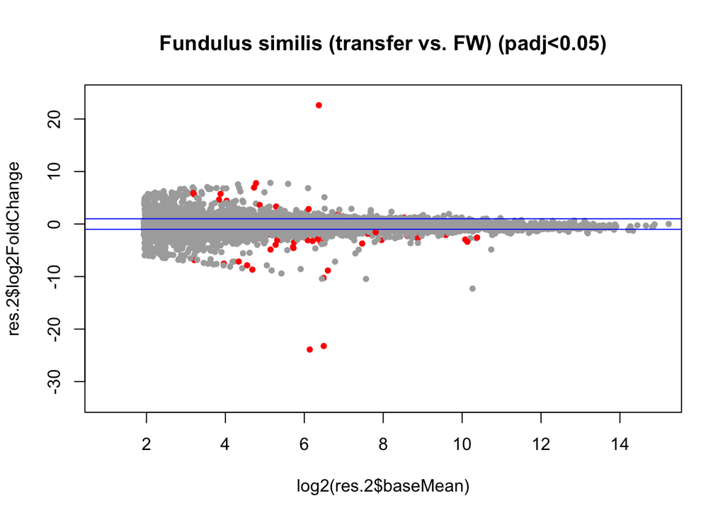

# MA plot, TR vs. BW

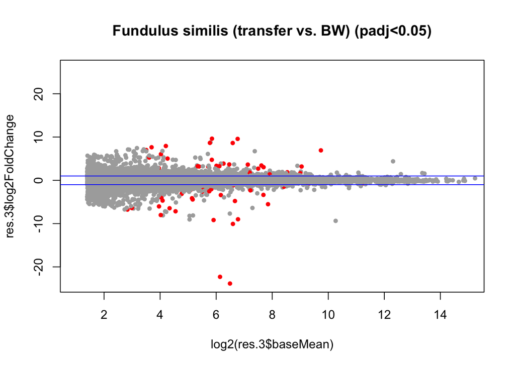

# Overlap of genes in each comparison

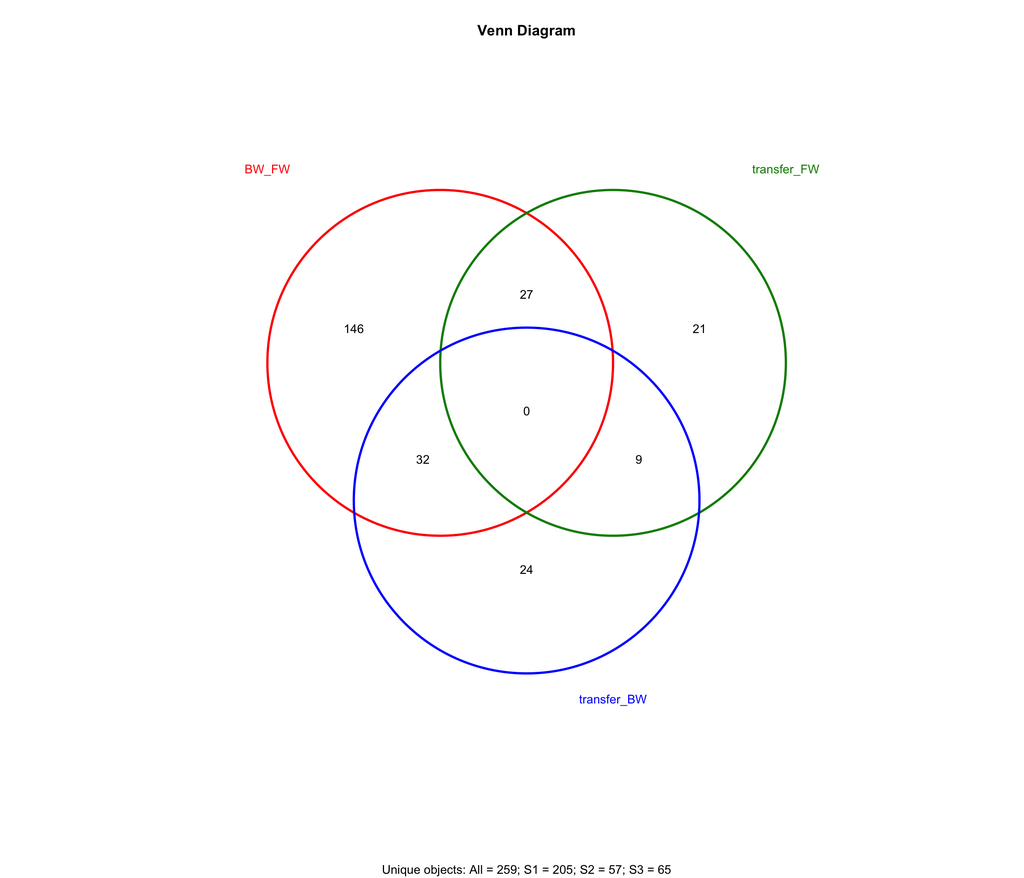

# Heatmap, Transfer vs. FW

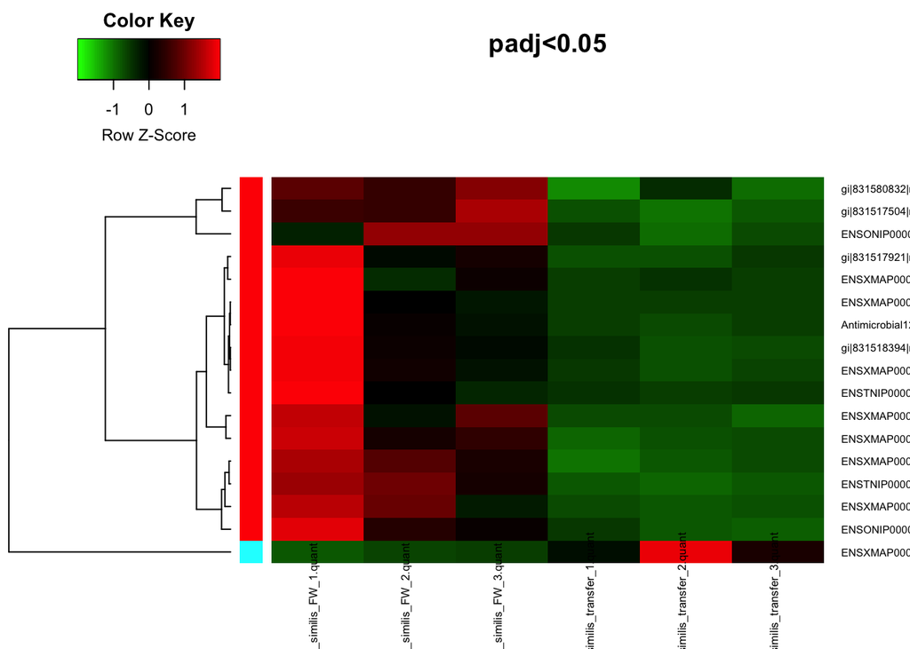

# Heatmap, Transfer vs. BW

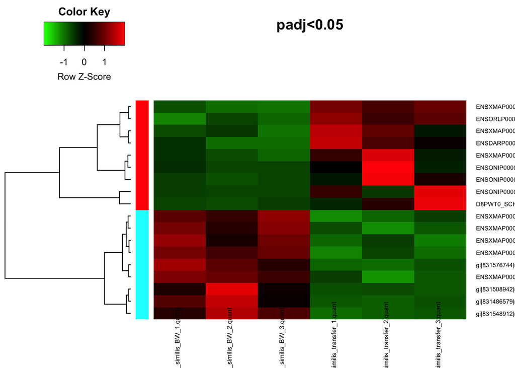

# Heatmap, BW vs. FW

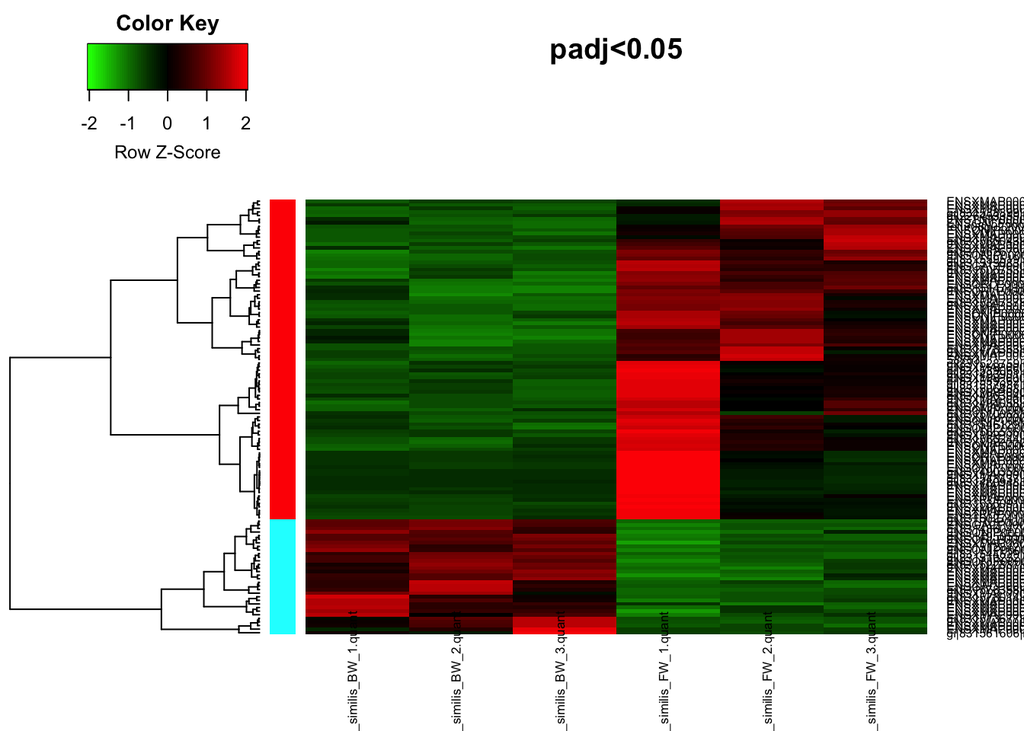

# Tables

```r
# merge gene_names, counts, and results for TR vs. BW, TR vs. FW, and BW vs. FW in one massive table
res.1<-as.data.frame(res.1)# BW vs. FW
cols<-c("baseMean_BW_v_FW","log2FC_BW_v_FW","lfcSE_BW_v_FW","stat_BW_v_FW","pvalue_BW_v_FW","padj_BW_v_FW")
colnames(res.1)<-cols
res.2<-as.data.frame(res.2)# TR vs. FW
cols<-c("baseMean_TR_v_FW","log2FC_TR_v_FW","lfcSE_TR_v_FW","stat_TR_v_FW","pvalue_TR_v_FW","padj_TR_v_FW")
colnames(res.2)<-cols
res.3<-as.data.frame(res.3)# TR vs. BW
cols<-c("baseMean_TR_v_BW","log2FC_TR_v_BW","lfcSE_TR_v_BW","stat_TR_v_BW","pvalue_TR_v_BW","padj_TR_v_BW")
colnames(res.3)<-cols
res.3<-as.data.frame(res.3)# TR vs. BW
#dim(counts_table)
GeneID<-rownames(res.1)
BW_FW_results<-cbind(res.1,GeneID)
GeneID<-rownames(res.2)
TR_FW_results<-cbind(res.2,GeneID)
GeneID<-rownames(res.3)
TR_BW_results<-cbind(res.3,GeneID)
GeneID<-rownames(counts_table)
counts_table_all<-cbind(counts_table,GeneID)
cols<-c("Row","Trinity_contigID","Trinity_gene","Trinity_gene2","dammit_ID","GeneID","dammit_ID2","NCBI_Fhet")
colnames(gene_names)<-cols
all_matrix<-merge(counts_table_all,TR_FW_results,by="GeneID")
all_matrix<-merge(all_matrix,TR_BW_results,by="GeneID")
all_matrix<-merge(all_matrix,BW_FW_results,by="GeneID")
all_matrix<-merge(all_matrix,gene_names,by="GeneID")
all_matrix <- all_matrix[,c(1:28,30,31,33,35)]
all_matrix <- all_matrix[order(all_matrix$padj_TR_v_FW),]
write.csv(all_matrix,"~/Documents/UCDavis/Whitehead/RNAseq_15killifish/DE_results/F_similis_DE_all.csv")
TR_BW_all<-all_matrix[all_matrix$GeneID %in% combined_transfer_BW,]
TR_BW_all <- TR_BW_all[order(TR_BW_all$padj_TR_v_BW),]
write.csv(TR_BW_all,"~/Documents/UCDavis/Whitehead/RNAseq_15killifish/DE_results/F_similis_DE_TR_BW.csv")
TR_FW_all<-all_matrix[all_matrix$GeneID %in% combined_transfer_FW,]
TR_FW_all <- TR_FW_all[order(TR_FW_all$padj_TR_v_FW),]
write.csv(TR_FW_all,"~/Documents/UCDavis/Whitehead/RNAseq_15killifish/DE_results/F_similis_DE_TR_FW.csv")
BW_FW_all<-all_matrix[all_matrix$GeneID %in% combined_BW_FW,]
BW_FW_all <- BW_FW_all[order(BW_FW_all$padj_BW_v_FW),]
write.csv(BW_FW_all,"~/Documents/UCDavis/Whitehead/RNAseq_15killifish/DE_results/F_similis_DE_BW_FW.csv")
```